# lung_pneumonia20190227

### Overview

In this competition, the primary endpoint will be the detection of bounding boxes corresponding to the diagnosis of pneumonia (e.g. lung infection) on chest radiographs, a special 2D high resolution grayscale medical image.

Note that pnuemonia is just one of many possible disease processes that can occur on a chest radiograph, and that any given single image may contain 0, 1 or many boxes corresponding to possible pneumonia location

### References :

```
https://www.kaggle.com/zahaviguy/what-are-lung-opacities
https://www.kaggle.com/aantonova/practical-eda-on-numerical-data
https://www.kaggle.com/giuliasavorgnan/data-leakage-viewposition-pa-ap-matters
https://www.kaggle.com/kmader/lung-opacity-overview # Good visulization

#segmentation cnn

use https://www.kaggle.com/hmendonca/mask-rcnn-and-coco-transfer-learning-lb-0-155
https://www.kaggle.com/jonnedtc/cnn-segmentation-connected-components

https://www.kaggle.com/drt2290078/mask-rcnn-sample-starter-code
```

## Import packages

```python
import os, sys, warnings, random, tqdm, glob, pylab, pandas as pd
import pydicom, numpy as np
import cv2
import seaborn as sns

from imgaug import augmenters as iaa
from sklearn.model_selection import KFold
```

```python
os.chdir('/Users/j/Dropbox/Learn/lung_pneumonia/')
```

```python
# Directory to save logs and trained model
work_DIR = '/Users/j/Dropbox/Learn/lung_pneumonia/models'
data_DIR = '/Users/j/Dropbox/Learn/lung_pneumonia/data/raw'
procesed_data_DIR = '/Users/j/Dropbox/Learn/lung_pneumonia/data/processed'
dicom_dir = '/Users/j/Dropbox/Learn/lung_pneumonia/data/raw/stage_2_train_images/'
```

```python
os.listdir()
```

```
['.DS_Store',
 'LICENSE',
 'requirements.txt',
 'references',
 'Makefile',
 'models',
 'docs',
 'README.md',
 'setup.py',
 '.gitignore',
 '.env',
 'tox.ini',
 'data',
 'notebooks',
 'test_environment.py',
 'reports',
 'src']
```

### Setting

```python
pd.set_option('display.max_columns',50)
warnings.filterwarnings("ignore")
```

## 1. EDA

```python
train_labels = pd.read_csv('data/raw/stage_2_train_labels.csv')
train_info = pd.read_csv('data/raw/stage_2_detailed_class_info.csv')
print(train_labels.head())
print(train_info.head())
```

```
                              patientId      x      y  width  height  Target
0  0004cfab-14fd-4e49-80ba-63a80b6bddd6    NaN    NaN    NaN     NaN       0
1  00313ee0-9eaa-42f4-b0ab-c148ed3241cd    NaN    NaN    NaN     NaN       0
2  00322d4d-1c29-4943-afc9-b6754be640eb    NaN    NaN    NaN     NaN       0
3  003d8fa0-6bf1-40ed-b54c-ac657f8495c5    NaN    NaN    NaN     NaN       0
4  00436515-870c-4b36-a041-de91049b9ab4  264.0  152.0  213.0   379.0       1
                              patientId                         class
0  0004cfab-14fd-4e49-80ba-63a80b6bddd6  No Lung Opacity / Not Normal
1  00313ee0-9eaa-42f4-b0ab-c148ed3241cd  No Lung Opacity / Not Normal
2  00322d4d-1c29-4943-afc9-b6754be640eb  No Lung Opacity / Not Normal
3  003d8fa0-6bf1-40ed-b54c-ac657f8495c5                        Normal
4  00436515-870c-4b36-a041-de91049b9ab4                  Lung Opacity
```

### Merge 1: train_labels and train_infor by joining on 'patientId'

```python
df_merge = pd.merge(train_labels,train_info, on='patientId',how='left')
print(df_merge.head())
```

```
                              patientId      x      y  width  height  Target  \
0  0004cfab-14fd-4e49-80ba-63a80b6bddd6    NaN    NaN    NaN     NaN       0
1  00313ee0-9eaa-42f4-b0ab-c148ed3241cd    NaN    NaN    NaN     NaN       0
2  00322d4d-1c29-4943-afc9-b6754be640eb    NaN    NaN    NaN     NaN       0
3  003d8fa0-6bf1-40ed-b54c-ac657f8495c5    NaN    NaN    NaN     NaN       0
4  00436515-870c-4b36-a041-de91049b9ab4  264.0  152.0  213.0   379.0       1

                          class
0  No Lung Opacity / Not Normal
1  No Lung Opacity / Not Normal
2  No Lung Opacity / Not Normal
3                        Normal
4                  Lung Opacity
```

```python
df_merge.to_csv('data/processed/df_train_labels_infor_merge.csv', index = False)
```

### What are the data fields?

The training data is provided as a set of patientIds and bounding boxes.

- x_ - the upper-left x coordinate of the bounding box.
- y_ - the upper-left y coordinate of the bounding box.
- width_ - the width of the bounding box.
- height_ - the height of the bounding box.

patientId *- A patientId. Each patientId corresponds to a unique image. Target* - the binary Target, indicating whether this sample has evidence of pneumonia.

- For Target =1, pneumonia, there is x, y, width, and height
- For Target = 0, non-pneumonia, these cells are blank

### 2. Remove replicates

```python
print(df_merge.info())
df_dropdup = df_merge.drop_duplicates()
print(df_dropdup.info())

df_dropdup.to_csv('data/processed/df_train_labels_infor_merge.csv', index = False)
```

```
<class 'pandas.core.frame.DataFrame'>
Int64Index: 37629 entries, 0 to 37628
Data columns (total 7 columns):
patientId    37629 non-null object
x            16957 non-null float64
y            16957 non-null float64
width        16957 non-null float64
height       16957 non-null float64
Target       37629 non-null int64
class        37629 non-null object
dtypes: float64(4), int64(1), object(2)
memory usage: 2.3+ MB
None
<class 'pandas.core.frame.DataFrame'>
Int64Index: 30227 entries, 0 to 37627
Data columns (total 7 columns):
patientId    30227 non-null object
x            9555 non-null float64
y            9555 non-null float64
width        9555 non-null float64
height       9555 non-null float64
Target       30227 non-null int64
class        30227 non-null object
dtypes: float64(4), int64(1), object(2)
memory usage: 1.8+ MB
None
```

### Yes, There are 7402 replicates in the train_label or train_info csv files

### *Check later:** are there replicates in the image folder???*

```python
df_dropdup.groupby(['class', 'Target']).size().reset_index(name=' Count')
```

|  | class | Target | Count |
| --- | --- | --- | --- |
| 0 | Lung Opacity | 1 | 9555 |
| 1 | No Lung Opacity / Not Normal | 0 | 11821 |
| 2 | Normal | 0 | 8851 |

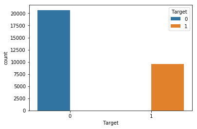

```python
# Count plot, x Target, color is target

sns.countplot(x = 'Target', hue = 'Target', data = df_dropdup)
```

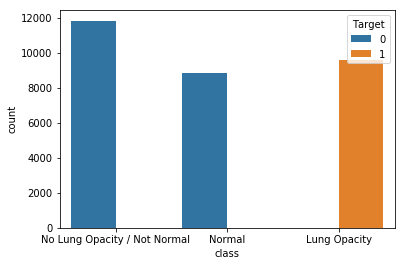

```python
sns.countplot(x = 'class', hue = 'Target', data = df_dropdup)
```

```python
print(df_dropdup['patientId'].value_counts().unique())

#Group by patientId and count
print(df_dropdup['patientId'].value_counts().value_counts())

# check the head
print(df_dropdup['patientId'].value_counts().head(5))
```

```
[4 3 2 1]
1    23286
2     3266
3      119
4       13
Name: patientId, dtype: int64
8dc8e54b-5b05-4dac-80b9-fa48878621e2    4
349f10b4-dc3e-4f3f-b2e4-a5b81448ce87    4
31764d54-ea3b-434f-bae2-8c579ed13799    4
0d5bc737-03de-4bb8-98a1-45b7180c3e0f    4
1c44e0a4-4612-438f-9a83-8d5bf919cb67    4
Name: patientId, dtype: int64
```

### 3: Merge with box counts

Yes. These are the number of bounding boxes for patients?

```python
box_counts = df_dropdup.groupby(['patientId','Target'])\
.size()\
.sort_values(ascending=False)\
.reset_index(name='boxes')
box_counts.head(2)
```

|  | patientId | Target | boxes |
| --- | --- | --- | --- |
| 0 | 7d674c82-5501-4730-92c5-d241fd6911e7 | 1 | 4 |
| 1 | 31764d54-ea3b-434f-bae2-8c579ed13799 | 1 | 4 |

```python
df_box = pd.merge(df_dropdup, box_counts, on = 'patientId',how='left')
df_box.head()

df_box.to_csv('data/processed/df_train_labels_infor_boxes_merge.csv', index = False)
```

[output not shown]

### 4. Summary of box count

```python
box_count_sum = df_box.\
    groupby('boxes').\
    size().\
    reset_index(name='patients')

box_count_sum.to_csv('/Users/j/Dropbox/Learn/lung_pneumonia/data/processed/df_boxe_count_sum.csv', index = False)
```

Yes. Target =1 group can have more than 1 picture. **Why?**

### 4. The size of boxes

```python
df_box['x_2'] = df_box['x'] + df_box['width']
df_box['y_2'] = df_box['y'] + df_box['height']
df_box['x_center'] = df_box['x'] + df_box['width'] / 2
df_box['y_center'] = df_box['y'] + df_box['height'] / 2
df_box['area'] = df_box['width'] * df_box['height']

print(df_box.head())
```

```
                              patientId      x      y  width  height  \
0  0004cfab-14fd-4e49-80ba-63a80b6bddd6    NaN    NaN    NaN     NaN
1  00313ee0-9eaa-42f4-b0ab-c148ed3241cd    NaN    NaN    NaN     NaN
2  00322d4d-1c29-4943-afc9-b6754be640eb    NaN    NaN    NaN     NaN
3  003d8fa0-6bf1-40ed-b54c-ac657f8495c5    NaN    NaN    NaN     NaN
4  00436515-870c-4b36-a041-de91049b9ab4  264.0  152.0  213.0   379.0

   Target_x                         class  Target_y  boxes    x_2    y_2  \
0         0  No Lung Opacity / Not Normal         0      1    NaN    NaN
1         0  No Lung Opacity / Not Normal         0      1    NaN    NaN
2         0  No Lung Opacity / Not Normal         0      1    NaN    NaN
3         0                        Normal         0      1    NaN    NaN
4         1                  Lung Opacity         1      2  477.0  531.0

   x_center  y_center     area
0       NaN       NaN      NaN
1       NaN       NaN      NaN
2       NaN       NaN      NaN
3       NaN       NaN      NaN
4     370.5     341.5  80727.0
```

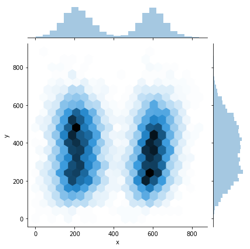

```python
# What are the upper boundaries of bounding boxes?
sns.jointplot(x = 'x', y = 'y', data = df_box,kind ='hex', gridsize = 20)
```

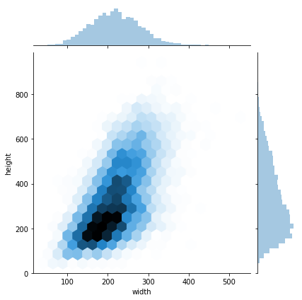

```python
# How big are the bounding boxes?
sns.jointplot(x = 'width', y = 'height', data = df_box,kind ='hex', gridsize = 20)
```

### Drop useless features in the meta data

Important factors to keep sex, age

## II Image Part

### How does a pneumonia DICOM image look like?

```python
train_path = "data/raw/stage_2_train_images/"
train_dicom = [f for f in os.listdir(train_path) if os.path.isfile(os.path.join(train_path, f))]

print(train_dicom[:1])
```

```
['7be6b4de-afe9-43c0-a581-0f49608c8976.dcm']
```

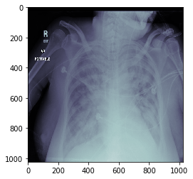

```python
# check an image with 4 boxes
# 7d674c82-5501-4730-92c5-d241fd6911e7
#doc
file = pydicom.read_file("data/raw/stage_2_train_images/7d674c82-5501-4730-92c5-d241fd6911e7.dcm")
import matplotlib.pyplot as plt

plt.imshow(file.pixel_array, cmap=plt.cm.bone)
```

```python
#file
# check size = Rows * Columns
```

## Add bounding boxes

```python
df_box[df_box['patientId'].str.match('7d674c82-5501-4730-92c5-d241fd6911e7')]
```

|  | patientId | x | y | width | height | Target_x | class | Target_y | boxes | x_2 | y_2 | x_center | y_center | area |
| --- | --- | --- | --- | --- | --- | --- | --- | --- | --- | --- | --- | --- | --- | --- |
| 12251 | 7d674c82-5501-4730-92c5-d241fd6911e7 | 358.0 | 320.0 | 159.0 | 186.0 | 1 | Lung Opacity | 1 | 4 | 517.0 | 506.0 | 437.5 | 413.0 | 29574.0 |
| 12252 | 7d674c82-5501-4730-92c5-d241fd6911e7 | 283.0 | 528.0 | 197.0 | 314.0 | 1 | Lung Opacity | 1 | 4 | 480.0 | 842.0 | 381.5 | 685.0 | 61858.0 |
| 12253 | 7d674c82-5501-4730-92c5-d241fd6911e7 | 718.0 | 573.0 | 133.0 | 227.0 | 1 | Lung Opacity | 1 | 4 | 851.0 | 800.0 | 784.5 | 686.5 | 30191.0 |
| 12254 | 7d674c82-5501-4730-92c5-d241fd6911e7 | 658.0 | 315.0 | 164.0 | 203.0 | 1 | Lung Opacity | 1 | 4 | 822.0 | 518.0 | 740.0 | 416.5 | 33292.0 |

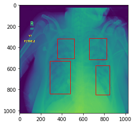

```python
import matplotlib.pyplot as plt
import matplotlib.patches as patches
from PIL import Image
import numpy as np
im = file.pixel_array
# Create figure and axes
fig,ax = plt.subplots(1)

# Display the image
ax.imshow(im)

# Create a Rectangle patch
rect1 = patches.Rectangle((358,320),159,186,linewidth=1,edgecolor='r',facecolor='none')
rect2 = patches.Rectangle((283,528),197,314,linewidth=1,edgecolor='r',facecolor='none')
rect3 = patches.Rectangle((718,573),133,277,linewidth=1,edgecolor='r',facecolor='none')
rect4 = patches.Rectangle((658,315),164,203,linewidth=1,edgecolor='r',facecolor='none')
# Add the patch to the Axes
ax.add_patch(rect1)
ax.add_patch(rect2)
ax.add_patch(rect3)
ax.add_patch(rect4)
plt.show()
```

## Sample sheet

```python
import pandas as pd
sample = pd.read_csv('/Users/j/Dropbox/Learn/lung_pneumonia/data/processed/sample_df_table.csv')
sample.head()
```

|  | patientId | x | y | width | height | Target_x | class | Target_y | boxes | path | class_idx | class_vec |
| --- | --- | --- | --- | --- | --- | --- | --- | --- | --- | --- | --- | --- |
| 0 | 6050f5be-e861-451b-80c4-0b79c9eaf9cc | NaN | NaN | NaN | NaN | 0 | No Lung Opacity / Not Normal | 0 | 1 | /Users/j/Dropbox/Learn/lung_pneumonia/data/raw... | 1 | [0.0, 1.0, 0.0] |
| 1 | fae7b1fc-10f3-492d-a79a-49061fe0059d | NaN | NaN | NaN | NaN | 0 | Normal | 0 | 1 | /Users/j/Dropbox/Learn/lung_pneumonia/data/raw... | 2 | [0.0, 0.0, 1.0] |
| 2 | 647b7bbc-5cfb-4776-b157-838a4264d318 | 244.0 | 528.0 | 218.0 | 236.0 | 1 | Lung Opacity | 1 | 1 | /Users/j/Dropbox/Learn/lung_pneumonia/data/raw... | 0 | [1.0, 0.0, 0.0] |
| 3 | b8c16a00-9fe8-412a-8a3b-972fc615eeda | 536.0 | 335.0 | 213.0 | 584.0 | 1 | Lung Opacity | 1 | 2 | /Users/j/Dropbox/Learn/lung_pneumonia/data/raw... | 0 | [1.0, 0.0, 0.0] |
| 4 | b8c16a00-9fe8-412a-8a3b-972fc615eeda | 172.0 | 279.0 | 216.0 | 575.0 | 1 | Lung Opacity | 1 | 2 | /Users/j/Dropbox/Learn/lung_pneumonia/data/raw... | 0 | [1.0, 0.0, 0.0] |

```python
sample_demo= sample[['patientId','class','Target_x']]

sample_demo['Gender'] = ''
sample_demo['age'] =''
sample_demo['size'] =''

sample_demo.head()
```

|  | patientId | class | Target_x | Gender | age | size |
| --- | --- | --- | --- | --- | --- | --- |
| 0 | 6050f5be-e861-451b-80c4-0b79c9eaf9cc | No Lung Opacity / Not Normal | 0 |  |  |  |
| 1 | fae7b1fc-10f3-492d-a79a-49061fe0059d | Normal | 0 |  |  |  |
| 2 | 647b7bbc-5cfb-4776-b157-838a4264d318 | Lung Opacity | 1 |  |  |  |
| 3 | b8c16a00-9fe8-412a-8a3b-972fc615eeda | Lung Opacity | 1 |  |  |  |
| 4 | b8c16a00-9fe8-412a-8a3b-972fc615eeda | Lung Opacity | 1 |  |  |  |

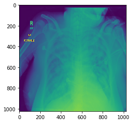

```python
#doc
neg = pydicom.read_file("data/raw/stage_2_train_images/4ba3e640-eb0a-4f4f-900c-af7405bc1790.dcm")
#plt.imshow(file.pixel_array, cmap=plt.cm.bone)
df_dropdup[df_dropdup['patientId'].str.match('4ba3e640-eb0a-4f4f-900c-af7405bc1790')]

im2 = neg.pixel_array
# Create figure and axes
fig,ax = plt.subplots(1)

# Display the image
ax.imshow(im)

# Create a Rectangle patch
# Add the patch to the Axes

plt.show()
```

# Model

## Transfer learning using MASK_RCNN

```python
# Import Mask RCNN
sys.path.append(os.path.join(work_DIR, 'Mask_RCNN'))  # To find local version of the library
from mrcnn.config import Config
from mrcnn import utils
import mrcnn.model as modellib
from mrcnn import visualize
from mrcnn.model import log
```

```python
train_dicom_dir = os.path.join(data_DIR, 'stage_2_train_images')
#test_dicom_dir = os.path.join(data_DIR, 'stage_2_test_images')
```

```python
### Download weights in the /models/weights directory
```

```python
os.chdir('/Users/j/Dropbox/Learn/lung_pneumonia/models/weights')
#!wget --quiet https://github.com/matterport/Mask_RCNN/releases/download/v2.0/mask_rcnn_coco.h5
```

```python
!ls -lh mask_rcnn_coco.h5
COCO_WEIGHTS_PATH = "mask_rcnn_coco.h5"
```

```
-rw-r--r--@ 1 j  staff   246M 26 Nov  2017 mask_rcnn_coco.h5
```

Some setup functions and classes for Mask-RCNN

- dicom_fps is a list of the dicom image path and filenames
- image_annotions is a dictionary of the annotations keyed by the filenames
- parsing the dataset returns a list of the image filenames and the annotations dictionary

```python
def get_dicom_fps(dicom_dir):
    dicom_fps = glob.glob(dicom_dir+'/'+'*.dcm') #a list of the dicom image path and filenames
    return list(set(dicom_fps))

def parse_dataset(dicom_dir, anns):
    image_fps = get_dicom_fps(dicom_dir)
    image_annotations = {fp: [] for fp in image_fps} #a dictionary of the annotations keyed by the filenames
    for index, row in anns.iterrows():
        fp = os.path.join(dicom_dir, row['patientId']+'.dcm')
        image_annotations[fp].append(row)
    return image_fps, image_annotations
```

```python
class DetectorConfig(Config):
    """Configuration for training pneumonia detection on the RSNA pneumonia dataset.
    Overrides values in the base Config class.
    """

    # Give the configuration a recognizable name
    NAME = 'pneumonia'

    # Train on 1 GPU and 8 images per GPU. We can put multiple images on each
    # GPU because the images are small. Batch size is 8 (GPUs * images/GPU).
    GPU_COUNT = 1
    IMAGES_PER_GPU = 8

    BACKBONE = 'resnet50'

    NUM_CLASSES = 2  # background + 1 pneumonia classes

    IMAGE_MIN_DIM = 256
    IMAGE_MAX_DIM = 256
    RPN_ANCHOR_SCALES = (16, 32, 64, 128)
    TRAIN_ROIS_PER_IMAGE = 32
    MAX_GT_INSTANCES = 4
    DETECTION_MAX_INSTANCES = 3
    DETECTION_MIN_CONFIDENCE = 0.78  ## match target distribution
    DETECTION_NMS_THRESHOLD = 0.01

    STEPS_PER_EPOCH = 200

config = DetectorConfig()
config.display()
```

```
Configurations:
BACKBONE                       resnet50
BACKBONE_STRIDES               [4, 8, 16, 32, 64]
BATCH_SIZE                     8
BBOX_STD_DEV                   [0.1 0.1 0.2 0.2]
COMPUTE_BACKBONE_SHAPE         None
DETECTION_MAX_INSTANCES        3
DETECTION_MIN_CONFIDENCE       0.78
DETECTION_NMS_THRESHOLD        0.01
FPN_CLASSIF_FC_LAYERS_SIZE     1024
GPU_COUNT                      1
GRADIENT_CLIP_NORM             5.0
IMAGES_PER_GPU                 8
IMAGE_CHANNEL_COUNT            3
IMAGE_MAX_DIM                  256
IMAGE_META_SIZE                14
IMAGE_MIN_DIM                  256
IMAGE_MIN_SCALE                0
IMAGE_RESIZE_MODE              square
IMAGE_SHAPE                    [256 256   3]
LEARNING_MOMENTUM              0.9
LEARNING_RATE                  0.001
LOSS_WEIGHTS                   {'rpn_class_loss': 1.0, 'rpn_bbox_loss': 1.0, 'mrcnn_class_loss': 1.0, 'mrcnn_bbox_loss': 1.0, 'mrcnn_mask_loss': 1.0}
MASK_POOL_SIZE                 14
MASK_SHAPE                     [28, 28]
MAX_GT_INSTANCES               4
MEAN_PIXEL                     [123.7 116.8 103.9]
MINI_MASK_SHAPE                (56, 56)
NAME                           pneumonia
NUM_CLASSES                    2
POOL_SIZE                      7
POST_NMS_ROIS_INFERENCE        1000
POST_NMS_ROIS_TRAINING         2000
PRE_NMS_LIMIT                  6000
ROI_POSITIVE_RATIO             0.33
RPN_ANCHOR_RATIOS              [0.5, 1, 2]
RPN_ANCHOR_SCALES              (16, 32, 64, 128)
RPN_ANCHOR_STRIDE              1
RPN_BBOX_STD_DEV               [0.1 0.1 0.2 0.2]
RPN_NMS_THRESHOLD              0.7
RPN_TRAIN_ANCHORS_PER_IMAGE    256
STEPS_PER_EPOCH                200
TOP_DOWN_PYRAMID_SIZE          256
TRAIN_BN                       False
TRAIN_ROIS_PER_IMAGE           32
USE_MINI_MASK                  True
USE_RPN_ROIS                   True
VALIDATION_STEPS               50
WEIGHT_DECAY                   0.0001
```

```python
class DetectorDataset(utils.Dataset):
    """Dataset class for training pneumonia detection on the RSNA pneumonia dataset.
    """

    def __init__(self, image_fps, image_annotations, orig_height, orig_width):
        super().__init__(self)

        # Add classes
        self.add_class('pneumonia', 1, 'Lung Opacity')

        # add images
        for i, fp in enumerate(image_fps):
            annotations = image_annotations[fp]
            self.add_image('pneumonia', image_id=i, path=fp,
                           annotations=annotations, orig_height=orig_height, orig_width=orig_width)

    def image_reference(self, image_id):
        info = self.image_info[image_id]
        return info['path']

    def load_image(self, image_id):
        info = self.image_info[image_id]
        fp = info['path']
        ds = pydicom.read_file(fp)
        image = ds.pixel_array
        # If grayscale. Convert to RGB for consistency.
        if len(image.shape) != 3 or image.shape[2] != 3:
            image = np.stack((image,) * 3, -1)
        return image

    def load_mask(self, image_id):
        info = self.image_info[image_id]
        annotations = info['annotations']
        count = len(annotations)
        if count == 0:
            mask = np.zeros((info['orig_height'], info['orig_width'], 1), dtype=np.uint8)
            class_ids = np.zeros((1,), dtype=np.int32)
        else:
            mask = np.zeros((info['orig_height'], info['orig_width'], count), dtype=np.uint8)
            class_ids = np.zeros((count,), dtype=np.int32)
            for i, a in enumerate(annotations):
                if a['Target'] == 1:
                    x = int(a['x'])
                    y = int(a['y'])
                    w = int(a['width'])
                    h = int(a['height'])
                    mask_instance = mask[:, :, i].copy()
                    cv2.rectangle(mask_instance, (x, y), (x+w, y+h), 255, -1)
                    mask[:, :, i] = mask_instance
                    class_ids[i] = 1
        return mask.astype(np.bool), class_ids.astype(np.int32)
    #Target_x and Target_y are the same as Target
```

### Match training csv and images

```python
# training dataset
#anns = pd.read_csv(os.path.join(procesed_data_DIR, 'df_train_labels_infor_boxes_merge.csv'))
#anns.head()
```

```python
image_fps, image_annotations = parse_dataset(train_dicom_dir, anns=anns)
```

```python
image_fps_list = list(image_fps)
random.seed(42)
random.shuffle(image_fps_list)


val_size = 1500
image_fps_val = image_fps_list[:val_size]
image_fps_train = image_fps_list[val_size:]

print(len(image_fps_train), len(image_fps_val))
#print(image_fps_val[:5])
```

```
25184 1500
```

```python
# prepare the training dataset
# Original DICOM image size: 1024 x 1024
ORIG_SIZE = 1024


dataset_train = DetectorDataset(image_fps_train, image_annotations, ORIG_SIZE, ORIG_SIZE)
dataset_train.prepare()

# Show annotation(s) for a DICOM image
test_fp = random.choice(image_fps_train)
image_annotations[test_fp]
```

```
[patientId    0a5b4860-e6ab-4737-a389-9d0cf7300770
 x                                             NaN
 y                                             NaN
 width                                         NaN
 height                                        NaN
 Target                                          0
 Name: 784, dtype: object]
```

```python
# prepare the validation dataset
dataset_val = DetectorDataset(image_fps_val, image_annotations, ORIG_SIZE, ORIG_SIZE)
dataset_val.prepare()
```

[output not shown]

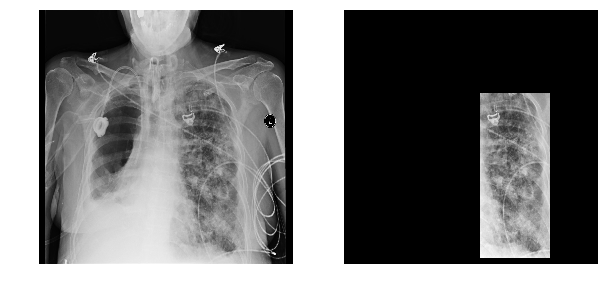

```python
# Load and display random sample and their bounding boxes

class_ids = [0]
while class_ids[0] == 0:  ## look for a mask
    image_id = random.choice(dataset_train.image_ids)
    image_fp = dataset_train.image_reference(image_id)
    image = dataset_train.load_image(image_id)
    mask, class_ids = dataset_train.load_mask(image_id)

print(image.shape)

plt.figure(figsize=(10, 10))
plt.subplot(1, 2, 1)
plt.imshow(image)
plt.axis('off')

plt.subplot(1, 2, 2)
masked = np.zeros(image.shape[:2])
for i in range(mask.shape[2]):
    masked += image[:, :, 0] * mask[:, :, i]
plt.imshow(masked, cmap='gray')
plt.axis('off')

print(image_fp)
print(class_ids)
```

```python
model = modellib.MaskRCNN(mode='training', config=config, model_dir=work_DIR)

# Exclude the last layers because they require a matching
# number of classes
model.load_weights(COCO_WEIGHTS_PATH, by_name=True, exclude=[
    "mrcnn_class_logits", "mrcnn_bbox_fc",
    "mrcnn_bbox", "mrcnn_mask"])
```

```python
LEARNING_RATE = 0.006
```

```python
%%time

## train heads with higher lr to speedup the learning
model.train(dataset_train, dataset_val,
            learning_rate=LEARNING_RATE*2,
            epochs=1,
            layers='heads',
            augmentation=None)  ## no need to augment yet

history = model.keras_model.history.history
```

```
Starting at epoch 0. LR=0.012

Checkpoint Path: /Users/j/Dropbox/Learn/lung_pneumonia/models/pneumonia20190227T1329/mask_rcnn_pneumonia_{epoch:04d}.h5
Selecting layers to train
fpn_c5p5               (Conv2D)
fpn_c4p4               (Conv2D)
fpn_c3p3               (Conv2D)
fpn_c2p2               (Conv2D)
fpn_p5                 (Conv2D)
fpn_p2                 (Conv2D)
fpn_p3                 (Conv2D)
fpn_p4                 (Conv2D)
In model:  rpn_model
    rpn_conv_shared        (Conv2D)
    rpn_class_raw          (Conv2D)
    rpn_bbox_pred          (Conv2D)
mrcnn_mask_conv1       (TimeDistributed)
mrcnn_mask_bn1         (TimeDistributed)
mrcnn_mask_conv2       (TimeDistributed)
mrcnn_mask_bn2         (TimeDistributed)
mrcnn_class_conv1      (TimeDistributed)
mrcnn_class_bn1        (TimeDistributed)
mrcnn_mask_conv3       (TimeDistributed)
mrcnn_mask_bn3         (TimeDistributed)
mrcnn_class_conv2      (TimeDistributed)
mrcnn_class_bn2        (TimeDistributed)
mrcnn_mask_conv4       (TimeDistributed)
mrcnn_mask_bn4         (TimeDistributed)
mrcnn_bbox_fc          (TimeDistributed)
mrcnn_mask_deconv      (TimeDistributed)
mrcnn_class_logits     (TimeDistributed)
mrcnn_mask             (TimeDistributed)
```

[output not shown]

[output cut: 14 more lines]

[output not shown]

```python
epochs = range(1,len(next(iter(history.values())))+1)
pd.DataFrame(history, index=epochs)
```

[output not shown]

## Errors

### make a table listing image path

```python
image_df = pd.DataFrame({'path': glob.glob(os.path.join(dicom_dir, '*.dcm'))})
image_df.head()
```

[output not shown]

```python
image_df['patientId'] = image_df['path'].map(lambda x: os.path.splitext(os.path.basename(x))[0])
```

```python
print(image_df.shape[0], 'images found')
img_pat_ids = set(image_df['patientId'].values.tolist())
box_pat_ids = set(df_box['patientId'].values.tolist())
# check to make sure there is no funny business
#assert img_pat_ids.union(box_pat_ids)==img_pat_ids, "Patient IDs should be the same"

#Reference :https://www.kaggle.com/kmader/lung-opacity-overview
```

```
26684 images found
```

```python
image_bbox_df = pd.merge(df_box,
                         image_df,
                         on='patientId',
                        how='left').sort_values('patientId')
print(image_bbox_df.shape[0], 'image bounding boxes')
print(image_bbox_df.head(5))
image_bbox_df.to_csv('/Users/j/Dropbox/Learn/lung_pneumonia/data/processed/df_boxe_count_sum.csv', index = False)
```

```
30227 image bounding boxes
                                  patientId      x      y  width  height  \
0      0004cfab-14fd-4e49-80ba-63a80b6bddd6    NaN    NaN    NaN     NaN
28989  000924cf-0f8d-42bd-9158-1af53881a557    NaN    NaN    NaN     NaN
28990  000db696-cf54-4385-b10b-6b16fbb3f985  316.0  318.0  170.0   478.0
28991  000db696-cf54-4385-b10b-6b16fbb3f985  660.0  375.0  146.0   402.0
28992  000fe35a-2649-43d4-b027-e67796d412e0  570.0  282.0  269.0   409.0

       Target_x                         class  Target_y  boxes  \
0             0  No Lung Opacity / Not Normal         0      1
28989         0                        Normal         0      1
28990         1                  Lung Opacity         1      2
28991         1                  Lung Opacity         1      2
28992         1                  Lung Opacity         1      2

                                                    path
0      /Users/j/Dropbox/Learn/lung_pneumonia/data/raw...
28989  /Users/j/Dropbox/Learn/lung_pneumonia/data/raw...
28990  /Users/j/Dropbox/Learn/lung_pneumonia/data/raw...
28991  /Users/j/Dropbox/Learn/lung_pneumonia/data/raw...
28992  /Users/j/Dropbox/Learn/lung_pneumonia/data/raw...
```

### Create a sample table

```python
# get the labels in the right format
from sklearn.preprocessing import LabelEncoder, OneHotEncoder
class_enc = LabelEncoder()
image_bbox_df['class_idx'] = class_enc.fit_transform(image_bbox_df['class'])
oh_enc = OneHotEncoder(sparse=False)
image_bbox_df['class_vec'] = oh_enc.fit_transform(
    image_bbox_df['class_idx'].values.reshape(-1, 1)).tolist()
image_bbox_df.sample(3)
```

|  | patientId | x | y | width | height | Target_x | class | Target_y | boxes | path | class_idx | class_vec |
| --- | --- | --- | --- | --- | --- | --- | --- | --- | --- | --- | --- | --- |
| 9165 | 654a61e7-07a9-4cb1-855f-a21ecba6fb18 | NaN | NaN | NaN | NaN | 0 | Normal | 0 | 1 | /Users/j/Dropbox/Learn/lung_pneumonia/data/raw... | 2 | [0.0, 0.0, 1.0] |
| 6428 | 4edd32a5-7960-41f5-a68a-df4744f3fe21 | 505.0 | 348.0 | 262.0 | 413.0 | 1 | Lung Opacity | 1 | 2 | /Users/j/Dropbox/Learn/lung_pneumonia/data/raw... | 0 | [1.0, 0.0, 0.0] |
| 11927 | 7adb12c0-b1b2-402e-9c58-5a8873eef61d | 259.0 | 543.0 | 144.0 | 110.0 | 1 | Lung Opacity | 1 | 1 | /Users/j/Dropbox/Learn/lung_pneumonia/data/raw... | 0 | [1.0, 0.0, 0.0] |

### Split the data into train and test

```python
from sklearn.model_selection import train_test_split
image_df = image_bbox_df.groupby('patientId').apply(lambda x: x.sample(1))
raw_train_df, valid_df = train_test_split(image_df, test_size=0.25, random_state=2018,
                                    stratify=image_df['class'])
print(raw_train_df.shape, 'training data')
print(valid_df.shape, 'validation data')
#https://www.kaggle.com/kmader/lung-opacity-classification-transfer-learning
```

```
(20013, 12) training data
(6671, 12) validation data
```

```python
raw_train_df.head()
```

| patientId |  | patientId | x | y | width | height | Target_x | class | Target_y | boxes | path | class_idx | class_vec |
| --- | --- | --- | --- | --- | --- | --- | --- | --- | --- | --- | --- | --- | --- |
| dff0a453-6507-489b-b524-41031c1306d9 | 24943 | dff0a453-6507-489b-b524-41031c1306d9 | NaN | NaN | NaN | NaN | 0 | No Lung Opacity / Not Normal | 0 | 1 | /Users/j/Dropbox/Learn/lung_pneumonia/data/raw... | 1 | [0.0, 1.0, 0.0] |
| ac36c55b-581a-4af8-bbf6-2334f565ce06 | 18183 | ac36c55b-581a-4af8-bbf6-2334f565ce06 | NaN | NaN | NaN | NaN | 0 | Normal | 0 | 1 | /Users/j/Dropbox/Learn/lung_pneumonia/data/raw... | 2 | [0.0, 0.0, 1.0] |
| c4f725aa-6f37-45ef-8e0f-f32882fad4b3 | 21705 | c4f725aa-6f37-45ef-8e0f-f32882fad4b3 | NaN | NaN | NaN | NaN | 0 | No Lung Opacity / Not Normal | 0 | 1 | /Users/j/Dropbox/Learn/lung_pneumonia/data/raw... | 1 | [0.0, 1.0, 0.0] |
| 7d44f498-340f-4afd-b5f4-f35a7124b35f | 12236 | 7d44f498-340f-4afd-b5f4-f35a7124b35f | NaN | NaN | NaN | NaN | 0 | No Lung Opacity / Not Normal | 0 | 1 | /Users/j/Dropbox/Learn/lung_pneumonia/data/raw... | 1 | [0.0, 1.0, 0.0] |
| 76c77e8d-bfc4-47b9-bffd-0d136fa06302 | 11417 | 76c77e8d-bfc4-47b9-bffd-0d136fa06302 | 328.0 | 509.0 | 124.0 | 111.0 | 1 | Lung Opacity | 1 | 1 | /Users/j/Dropbox/Learn/lung_pneumonia/data/raw... | 0 | [1.0, 0.0, 0.0] |

```python
from keras.preprocessing.image import ImageDataGenerator
```

```python
img_gen_args = dict(samplewise_center=False,
                              samplewise_std_normalization=False,
                              horizontal_flip = True,
                              vertical_flip = False,
                              height_shift_range = 0.05,
                              width_shift_range = 0.02,
                              rotation_range = 3,
                              shear_range = 0.01,
                              fill_mode = 'nearest',
                              zoom_range = 0.05,
                               preprocessing_function=COCO_WEIGHTS_PATH)
img_gen = ImageDataGenerator(**img_gen_args)
```

```python
def flow_from_dataframe(img_data_gen, in_df, path_col, y_col, seed = None, **dflow_args):
    base_dir = os.path.dirname(in_df[path_col].values[0])
    print('## Ignore next message from keras, values are replaced anyways: seed: {}'.format(seed))
    df_gen = img_data_gen.flow_from_directory(base_dir,
                                     class_mode = 'sparse',
                                              seed = seed,
                                    **dflow_args)
    df_gen.filenames = in_df[path_col].values
    df_gen.classes = np.stack(in_df[y_col].values,0)
    df_gen.samples = in_df.shape[0]
    df_gen.n = in_df.shape[0]
    df_gen._set_index_array()
    df_gen.directory = '' # since we have the full path
    print('Reinserting dataframe: {} images'.format(in_df.shape[0]))
    return df_gen
```

```python
sample_df = image_bbox_df.\
    groupby(['Target_x','class', 'boxes']).\
    apply(lambda x: x[x['patientId']==x.sample(1)['patientId'].values[0]]).\
    reset_index(drop=True)
print(sample_df.head(2))
sample_df.to_csv('/Users/j/Dropbox/Learn/lung_pneumonia/data/processed/sample_df_table.csv', index=False)
```

```
                              patientId   x   y  width  height  Target_x  \
0  6050f5be-e861-451b-80c4-0b79c9eaf9cc NaN NaN    NaN     NaN         0
1  fae7b1fc-10f3-492d-a79a-49061fe0059d NaN NaN    NaN     NaN         0

                          class  Target_y  boxes  \
0  No Lung Opacity / Not Normal         0      1
1                        Normal         0      1

                                                path  class_idx  \
0  /Users/j/Dropbox/Learn/lung_pneumonia/data/raw...          1
1  /Users/j/Dropbox/Learn/lung_pneumonia/data/raw...          2

         class_vec
0  [0.0, 1.0, 0.0]
1  [0.0, 0.0, 1.0]
```

```python
IMG_SIZE = (384, 384)

BATCH_SIZE = 24 # [1, 8, 16, 24]
DENSE_COUNT = 128 # [32, 64, 128, 256]
DROPOUT = 0.25 # [0, 0.25, 0.5]
LEARN_RATE = 0.006 # [1e-4, 1e-3, 4e-3]
TRAIN_SAMPLES = 8000 # [3000, 6000, 15000]
TEST_SAMPLES = 800
USE_ATTN = False # [True, False]
```

```python
train_gen = flow_from_dataframe(img_gen, raw_train_df,
                             path_col = 'path',
                            y_col = 'class_vec',
                            target_size = IMG_SIZE,
                             color_mode = 'rgb',
                            batch_size = BATCH_SIZE)
```

```
## Ignore next message from keras, values are replaced anyways: seed: None
Found 0 images belonging to 0 classes.
Reinserting dataframe: 20013 images
```

```python
%%time

## train heads with higher lr to speedup the learning
model.train(train_gen, valid_gen,
            learning_rate=LEARNING_RATE*2,
            epochs=1,
            layers='heads',
            augmentation=None)  ## no need to augment yet

history = model.keras_model.history.history
```

```
Starting at epoch 0. LR=0.012

Checkpoint Path: /Users/j/Dropbox/Learn/lung_pneumonia/models/pneumonia20190227T1329/mask_rcnn_pneumonia_{epoch:04d}.h5
Selecting layers to train
fpn_c5p5               (Conv2D)
fpn_c4p4               (Conv2D)
fpn_c3p3               (Conv2D)
fpn_c2p2               (Conv2D)
fpn_p5                 (Conv2D)
fpn_p2                 (Conv2D)
fpn_p3                 (Conv2D)
fpn_p4                 (Conv2D)
In model:  rpn_model
    rpn_conv_shared        (Conv2D)
    rpn_class_raw          (Conv2D)
    rpn_bbox_pred          (Conv2D)
mrcnn_mask_conv1       (TimeDistributed)
mrcnn_mask_bn1         (TimeDistributed)
mrcnn_mask_conv2       (TimeDistributed)
mrcnn_mask_bn2         (TimeDistributed)
mrcnn_class_conv1      (TimeDistributed)
mrcnn_class_bn1        (TimeDistributed)
mrcnn_mask_conv3       (TimeDistributed)
mrcnn_mask_bn3         (TimeDistributed)
mrcnn_class_conv2      (TimeDistributed)
mrcnn_class_bn2        (TimeDistributed)
mrcnn_mask_conv4       (TimeDistributed)
mrcnn_mask_bn4         (TimeDistributed)
mrcnn_bbox_fc          (TimeDistributed)
mrcnn_mask_deconv      (TimeDistributed)
mrcnn_class_logits     (TimeDistributed)
mrcnn_mask             (TimeDistributed)
```

[output not shown]

[output cut: 19 more lines]

[output not shown]

```python
valid_gen = flow_from_dataframe(img_gen, valid_df,
                             path_col = 'path',
                            y_col = 'class_vec',
                            target_size = IMG_SIZE,
                             color_mode = 'rgb',
                            batch_size = 256) # we can use much larger batches for evaluation
```

```
## Ignore next message from keras, values are replaced anyways: seed: None
Found 0 images belonging to 0 classes.
Reinserting dataframe: 6671 images
```

```python
# used a fixed dataset for evaluating the algorithm
valid_X, valid_Y = next(flow_from_dataframe(img_gen, valid_df,
                             path_col = 'path',
                            y_col = 'class_vec',
                            target_size = IMG_SIZE,
                             color_mode = 'rgb',
                            batch_size = TEST_SAMPLES)) # one big batch
```

```
## Ignore next message from keras, values are replaced anyways: seed: None
Found 0 images belonging to 0 classes.
Reinserting dataframe: 6671 images
```

[output not shown]

```python
valid_gen = flow_from_dataframe(img_gen, valid_df,
                             path_col = 'path',
                            y_col = 'class_vec',
                            target_size = IMG_SIZE,
                             color_mode = 'rgb',
                            batch_size = 256) # we can use much larger batches for evaluation
# used a fixed dataset for evaluating the algorithm
valid_X, valid_Y = next(flow_from_dataframe(img_gen,
                               valid_df,
                             path_col = 'path',
                            y_col = 'class_vec',
                            target_size = IMG_SIZE,
                             color_mode = 'rgb',
                            batch_size = TEST_SAMPLES)) # one big batch
```

```python
## Backups
from sklearn.model_selection import train_test_split
image_df = image_bbox_df.groupby('patientId').apply(lambda x: x.sample(1))
raw_train_df, valid_df = train_test_split(image_df, test_size=0.25, random_state=2018,
                                    stratify=image_df['class'])
print(raw_train_df.shape, 'training data')
print(valid_df.shape, 'validation data')
```

```
(20013, 10) training data
(6671, 10) validation data
```